# Einführung in R

# Einleitung

Wir können mit R einfache mathematische Operationen ausführen:

```r
1 + 1
```

```
## [1] 2
```

```r
1 * 2
```

```
## [1] 2
```

```r
6 / 3 - 1
```

```
## [1] 1
```

```r
(2^5)/13
```

```
## [1] 2.461538
```

In R kann alles mit `<-` oder `=` in Variablen gespeichert werden.

```r
x <- 1 + 1
x
```

```
## [1] 2
```

oder

```r
x = 1 + 1
```

# Objektklassen

Diese Variablen werden in R in der Regel Objekte genannt. Jedes Objekt hat eine Objektklasse, die bestimmt welche Funktionen auf sie angewandt werden können oder wie Funktionen mit den Objekten umgehen. Mit der `class()` Funktion können wir uns die Klasse eines Objektes anzeigen lassen.

```r
class(x)
```

```
## [1] "numeric"
```

Die Klasse von `x` ist also `numeric` - eine Kommazahl.

```r
x <- "a"
class(x)
```

```
## [1] "character"
```

Buchstaben oder Texte werden als `character` bezeichnet. Achte darauf das character immer durch Anführungszeichen markiert sind und alles was mit Anführungszeichen markiert ist, ist ein character. Was glaubst du sind die Klassen dieser drei Objekte? Denke darüber nach und dann probier es aus.

```r
x <- 1
y <- x
z <- "1"
```

Die letzte wichtige Klasse sind logische Werte also `TRUE` und `FALSE` R nennt solche Objekte `logical`

```r
x <- TRUE
class(x)
```

```
## [1] "logical"
```

In der Regel weist man Objekten nicht direkt TRUE oder FALSE zu, sondern evaluiert eine Aussage. Zum Beispiel:

```r
a <- 5
b <- 6
x <- a > b
x
```

```
## [1] FALSE
```

Später, im Abschnitt “Grundlagen des Progammierens mit R”, werden wir Beispiele kennenlernen für die logische Werte nützlich sind.

Nicht alle Objekte bestehen nur aus einem Element. Hier zeige ich euch vier Objektklassen die aus mehreren Elementen bestehen: Vektoren, Listen, Matrizen und data.frames.

Vektoren sind die einfachste Klasse mit mehreren Elementen. Sie werden mit der Funktion `c()` gebildet.

```r
x <- c(1,2,3,4,5)
```

Die einzelnen Elemente werden durch Kommata getrennt. Die Elemente müssen keine Zahlen sein, aber alle Elemente müssen die gleiche Klasse haben. Wenn wir das hier probieren:

```r
x <- c(1, "a")
```

Wir die 1 automatisch in einen charachter umgewandelt. Auf die einzelnen Elemente können wir mit `[]` zugreifen. So ist

```r
x[2]
```

```
## [1] "a"
```

das zweite Element von `x`. Das Zugreifen auf einzelne Elemente wird auch als “subsetten” bezeichnet, da wir den Vektor auf eine Untermenge (subset) reduzieren. Man kann auch mit Vektoren subsetten.

```r
y <- c(4,7,1,9,3,7)
x <- c(1,2,3)
z <- y[x]
```

Die zweite Klasse mit mehreren Elementen ist die Liste.

```r
x <- list(1,2,3)
x
```

```
## [[1]]
## [1] 1
##
## [[2]]
## [1] 2
##
## [[3]]
## [1] 3
```

```r
class(x)
```

```
## [1] "list"
```

Im Gegensatz zu Vektoren können Listen auch Objekte verschiedener Klassen speichern.

```r
x <- list(1, "a", TRUE)
x
```

```
## [[1]]
## [1] 1
##
## [[2]]
## [1] "a"
##
## [[3]]
## [1] TRUE
```

Sogar Elemente mit mehreren Elementen sind möglich.

```r
x <- list(c(1,2,3), "a", TRUE)
```

Um eine Liste zu subsetten benutzen wir `[[]]`.

```r
x[[1]]
```

```
## [1] 1 2 3
```

Benutzen wir nur eine Klammer erhalten wir keinen Fehler sondern das erste Listenelement, aber immernoch als Liste. Also `x[1][[1]]` ist das Gleiche wie `x[[1]]` und `x[2][[1]]` ist das Gleiche wie `x[[2]]`. Das gilt nicht mehr wenn die Elemente der Liste selber Listen sind, aber das dürfte in diesem Kurs nicht vorkommen.

```r
x[1][[1]] == x[[1]]
```

```
## [1] TRUE TRUE TRUE
```

```r
x[2]
```

```
## [[1]]
## [1] "a"
```

Eine Matrix hat im Gegensatz zu Vektoren und Listen zwei Dimensionen. Also Zeilen und Spalten. Genau wie beim Vektor können Matrizen numerical, logical und character Objekte beinhalten aber nicht alles gleichzeitig.

```r
x <- matrix(data = c(1:9), nrow = 3, ncol = 3)
```

Matrizen werden wie Vektoren mit `[` subsettet, aber da es nun Zeilen und Spalten gibt können wir zwei Werte angeben.

```r
x[1,1] # erste Zeile, erste Spalte
```

```
## [1] 1
```

```r
x[1,3] # erste Zeile, dritte Spalte
```

```
## [1] 7
```

```r
x[1, ] # erste Zeile, alle Spalten
```

```
## [1] 1 4 7
```

Die lezte Objektklasse sind data.frames. Die kommen der gew?hnlichen Tabelle am nächsten. Im Gegensatz zur Matrix können die Spalten unterschiedliche Klassen enthalten. Eine Spalte muss aber immer eine Klasse enthalten.

```r
x <- data.frame(a = c(1,2,3),
           b = c(4,5,6),
           c = c (7,8,9))
```

Data.frames können genauso subsettet werden wie Matrizen. Da die einzelnen Spalten eines data.frames aber auch namen haben (hier `a`, `b` und `c`), können wir auch diese nutzen.

```r
x$a
```

```
## [1] 1 2 3
```

oder

```r
x["a"]
```

```
##   a
## 1 1
## 2 2
## 3 3
```

Wie ihr seht unterscheiden sich die Ergebnisse etwas. Währent `x$a` einen Vektor produziert, bekommen wir bei `x["a"]` einen data.frame mit einer Spalte.

# Wichtige Funktionen

Im vorherigen Abschnitt habt ihr bereits einige Funktion benutzt: `class()`, `c()`, `list()`, `matrix()`, `data.frame()`. Sogar `+`, `-`, `[` und so weiter sind in R Funktionen. Allerdings spezielle Funktionen die wir hier in ihrem Aufbau nicht näher betrachten werden (aber siehe [hier](https://www.datamentor.io/r-programming/infix-operator/) für eine kurze Erklärung bei Interesse). Alle “normalen” Funktionen haben einen gemeinsamen Aufbau: der Funktionsname gefolgt von runden Klammern. In den Klammern sind die sogenannten Argumente. Mit einem Fragezeichen

```r
?c()
```

oder indem ihr den Namen auswählt und F1 drückt bekommt ihr ein Hilfefenster. In diesem Fenster findet ihr alle Argumente sowie deren Erklärungen.

In diesem Abschnitt möchte ich euch einige nützliche Funktionen vorstellen.

## R PACKAGES

Eine der großen Stärken von R ist, dass es kontinuerilich durch neue Addons, sogennante Packages, erweitert wird. Um diese Packages zu nutzen müsst ihr sie zuerst installieren. Hier am Beispiel des Packages `dplyr`, das wir später genauer betrachten werden.

```r
install.packages("dplyr")
```

Ein Package muss nur einmal installiert werden, wie jede andere Software auch. Wenn das Package bereits installiert ist, k?nnt ihr es mit

```r
library(dplyr)
```

oder

```r
require(dplyr)
```

laden. Nun stehen euch die Funktionen aus dem Package zur Verfügung. Ihr könnt die Funktionen auch nutzen ohne das ganze Package zu laden indem ihr die `::` Notation nutzt. Wenn ihr `dplyr::` eingebt werden euch alle Funktionen aus dem Package angezeigt. Wenn ihr diese gewünschte Funktion nun dahinter schreibt, z.B. `dplyr::select()` könnt ihr sie auch nutzen ohne zuerst dplyr zu laden.

## DATEN EINLESEN

In vielen Fällen habt ihr bereits Daten erhoben, runtergeladen und von zugeschickt bekommen. Diese kommen leider in allen Farben und Formen und ein großer Teil der praktischen Arbeit besteht darin die Daten in ein nützliches Format zu überführen. Hier zeige ich euch wege um drei übliche Dateiformate einzulesen: csv, xlsx und rds.

Bevor wir die Datei lesen können, können wir R sagen in welchem Ordner wir arbeiten, damit wir die Dateien schneller finden. Dieser “Arbeitsordner” ist das working directory (wd). Das aktuelle wd bekommen wir mit

```r
getwd()
```

```
## [1] "C:/Users/jonat/Documents/Uni/teaching/GIS/landau_bachelor_2/22_23_Lecture/01_lecture1"
```

angezeigt. Ändern können wir es mit:

```r
setwd("~/Uni/teaching/GIS/")
```

Den Inhalt der Klammern müsst dabei ihr an eure Ordnerstuktur anpassen.

### csv

```r
test_csv <- read.csv(file = "beispiel.csv")
```

### xlsx

Excel Dateien können nicht ohne Package gelesen werden. Abhilfe leisten die Packages `xlsx` und `readxl`.

```r
install.packages("xlsx")
test_excel <- xlsx::read.xlsx(file = "beispiel.xlsx", sheetIndex = 1)
```

### RDS

RDS ist ein Datenformat nur für R. Wenn ihr Daten aus R speichert nur um sie später wieder in R zu laden und keine anderen Programme nutzen wollt, ist RDS die beste Wahl.

```r
test_rds <- readRDS("beispiel.rds")
```

## Mathematische Funktionen

Zuerst erstellen wir einen Vektor (`x`) und einen data.frame (`y`) an dennen wir die Funktionen demonstrieren können.

```r
x <- c(1:100)
y <- data.frame(a = c(1, 2, 3),
                b = c(4, 5, 6),
                c = c (7, 8, 9))
```

Summe:

```r
sum(x)
```

```
## [1] 5050
```

```r
sum(y)
```

```
## [1] 45
```

Arithmetische Mittelwert:

```r
mean(x)
```

```
## [1] 50.5
```

Standardabweichung:

```r
sd(x)
```

```
## [1] 29.01149
```

Höchste Wert:

```r
max(x)
```

```
## [1] 100
```

```r
max(y)
```

```
## [1] 9
```

Niedrigste Wert:

```r
min(x)
```

```
## [1] 1
```

```r
min(y)
```

```
## [1] 1
```

Quadratwurzel:

```r
sqrt(x)
```

```
##   [1]  1.000000  1.414214  1.732051  2.000000  2.236068  2.449490  2.645751
##   [8]  2.828427  3.000000  3.162278  3.316625  3.464102  3.605551  3.741657
##  [15]  3.872983  4.000000  4.123106  4.242641  4.358899  4.472136  4.582576
##  [22]  4.690416  4.795832  4.898979  5.000000  5.099020  5.196152  5.291503
##  [29]  5.385165  5.477226  5.567764  5.656854  5.744563  5.830952  5.916080
##  [36]  6.000000  6.082763  6.164414  6.244998  6.324555  6.403124  6.480741
##  [43]  6.557439  6.633250  6.708204  6.782330  6.855655  6.928203  7.000000
##  [50]  7.071068  7.141428  7.211103  7.280110  7.348469  7.416198  7.483315
##  [57]  7.549834  7.615773  7.681146  7.745967  7.810250  7.874008  7.937254
##  [64]  8.000000  8.062258  8.124038  8.185353  8.246211  8.306624  8.366600
##  [71]  8.426150  8.485281  8.544004  8.602325  8.660254  8.717798  8.774964
##  [78]  8.831761  8.888194  8.944272  9.000000  9.055385  9.110434  9.165151
##  [85]  9.219544  9.273618  9.327379  9.380832  9.433981  9.486833  9.539392
##  [92]  9.591663  9.643651  9.695360  9.746794  9.797959  9.848858  9.899495
##  [99]  9.949874 10.000000
```

```r
sqrt(y)
```

```
##          a        b        c
## 1 1.000000 2.000000 2.645751
## 2 1.414214 2.236068 2.828427
## 3 1.732051 2.449490 3.000000
```

## Sonstige Funktionen

Wie viele Elemente hat ein Vektor. Nicht die Länge des Vektors im mathematischen Sinn. Bei Data.frames ist es die Anzahl der Spalten.

```r
length(x)
```

```
## [1] 100
```

```r
length(y)
```

```
## [1] 3
```

Füge hinten an den Vektor x die Werte “values” an.

```r
append(x = x, values = 1)
```

```
##   [1]   1   2   3   4   5   6   7   8   9  10  11  12  13  14  15  16  17  18
##  [19]  19  20  21  22  23  24  25  26  27  28  29  30  31  32  33  34  35  36
##  [37]  37  38  39  40  41  42  43  44  45  46  47  48  49  50  51  52  53  54
##  [55]  55  56  57  58  59  60  61  62  63  64  65  66  67  68  69  70  71  72
##  [73]  73  74  75  76  77  78  79  80  81  82  83  84  85  86  87  88  89  90
##  [91]  91  92  93  94  95  96  97  98  99 100   1
```

Struktur des Objektes:

`int` ist kurz für Integer, eine ganze Zahl.

```r
str(x)
```

```
##  int [1:100] 1 2 3 4 5 6 7 8 9 10 ...
```

```r
str(y)
```

```
## 'data.frame':    3 obs. of  3 variables:
##  $ a: num  1 2 3
##  $ b: num  4 5 6
##  $ c: num  7 8 9
```

Zusammenfassung eines Objektes

```r
summary(x)
```

```
##    Min. 1st Qu.  Median    Mean 3rd Qu.    Max.
##    1.00   25.75   50.50   50.50   75.25  100.00
```

```r
summary(y)
```

```
##        a             b             c
##  Min.   :1.0   Min.   :4.0   Min.   :7.0
##  1st Qu.:1.5   1st Qu.:4.5   1st Qu.:7.5
##  Median :2.0   Median :5.0   Median :8.0
##  Mean   :2.0   Mean   :5.0   Mean   :8.0
##  3rd Qu.:2.5   3rd Qu.:5.5   3rd Qu.:8.5
##  Max.   :3.0   Max.   :6.0   Max.   :9.0
```

Zeige die ersten 6 Zeilen einer Matrix oder eines data.frames

```r
head(y)
```

```
##   a b c
## 1 1 4 7
## 2 2 5 8
## 3 3 6 9
```

Auflistung aller erstellten Objekte.

```r
ls()
```

```
## [1] "a"        "b"        "test_csv" "test_rds" "x"        "y"        "z"
```

Löschen von Objekten

```r
rm(x)
```

Erstellen von Graphiken. Hier wird bei der Eingabe die “Formula” Notation verwandt. Sie lässt sich hier als “a erklärt durch b” lesen. Die gleiche Notation wird auch für Regressionsmodelle verwandt.

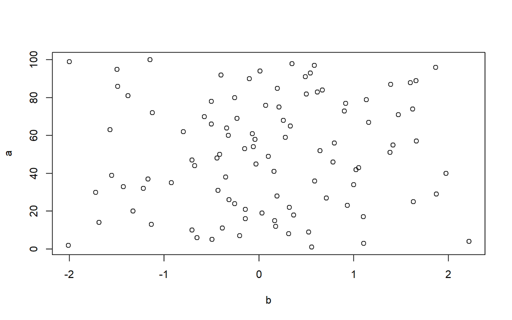

```r
a <- c(1:100)
b <- rnorm(100)
plot(a ~ b)
```

# Grundlagen des Progammierens mit R

Hier möchte ich euch vier Fundamentale Programmier Bausteine zeigen:  
1. Eigene Funktionen schreiben  
2. If-clause  
3. For-loop  
4. while-loop

## Eigene Funktionen schreiben

In R sind wir nicht auf die Funktionen angewiesen, die jemand anderes geschrieben hat, sondern können auch unsere eigenen Funktionen schreiben. Die Funktion `add_one`, zum Beispiel, nimmt eine Zahl `x` und fügt eins hinzu.

```r
add_one <- function(x){
        x + 1
}
add_one(4)
```

```
## [1] 5
```

Die Funktion `add_y` fügt einen Wert y hinzu, der als Argument angegeben werden muss.

```r
add_y <- function(x,y){
        x + y
}
add_y(4,5)
```

```
## [1] 9
```

Wir können auch einen Standardwert für das y Argumente angeben. Falls der Nutzer keinen Wert angibt wird dieser benutzt.

```r
add_y2 <- function(x,y = 1){
        x + y
}
add_y(2,1)
```

```
## [1] 3
```

```r
add_y2(2)
```

```
## [1] 3
```

Die Anzahl der Schritte innerhalb der Funktion ist beliebig.

```r
add_sub_mult_xyz <- function(w,x= 10,y = 20, z = 2){
        out <- w + x
        out <- out - y
        out <- out * z
        return(out)
}
add_sub_mult_xyz(2)
```

```
## [1] -16
```

## If-clause

Ein If-clause evaluiert eine logische Aussage (z.B. x ist größer y oder x ist gleich 3) und führt eine Aktion aus falls die Aussage wahr ist.

```r
x = 1
y = 2

if (x > y){
        print("x")
} else {
        print("y")
}
```

```
## [1] "y"
```

In einer Funktion können wir einen if-clause z.b. so benutzen

```r
change_x <- function(x, y, operation = "add"){

        if (operation == "add"){
              out <- x + y
        } else if (operation == "subtract") {
                out <- x - y
        } else if (operation == "multiply") {
                out <- x * y
        } else if (operation == "divide") {
                out <- x/y
        }
        return(out)
}
```

## For Loop

In machen Situationen möchte man die gleiche Funktion oder die gleiche Folge an Funktionen (Alogrithmus) auf mehrere Elemente anweden. Anstatt denn gleichen Code mehrmals zu schreiben und immer das Objekt zu tauschen, können wir ein for-loop verweden. Ein for loop führt seinen Code immer wieder aus. In jedem Durchlauf ändert sich der Wert einer entscheidenden Variable. Im folgenden Beispiel ist dies `i`. `i` nimmt jeden Wert zwischen 1 und 10 an und wird ausgegeben.

```r
for (i in 1:10){
        print(i)
}
```

```
## [1] 1
## [1] 2
## [1] 3
## [1] 4
## [1] 5
## [1] 6
## [1] 7
## [1] 8
## [1] 9
## [1] 10
```

Es folgen einige selbsterklärende Loops.

```r
for (k in 1:10){
        if (k == 1) x <- 0
        x <- x + k
        print(x)
}
```

```
## [1] 1
## [1] 3
## [1] 6
## [1] 10
## [1] 15
## [1] 21
## [1] 28
## [1] 36
## [1] 45
## [1] 55
```

```r
for (i in c("a", "b", "c")){
        print(i)
}
```

```
## [1] "a"
## [1] "b"
## [1] "c"
```

```r
for (i in 1:10){
        ## %% der Rest der Division
        if ( i %% 2 == 0){
                out <- "gerade"
        } else {
                out <- "ungerade"
        }
        print(out)
}
```

```
## [1] "ungerade"
## [1] "gerade"
## [1] "ungerade"
## [1] "gerade"
## [1] "ungerade"
## [1] "gerade"
## [1] "ungerade"
## [1] "gerade"
## [1] "ungerade"
## [1] "gerade"
```

## While loops

While loops laufen nicht bis ihr Index (`i` im unseren for-loops) durchgelaufen ist, sondern bis eine logische Aussage falsch ist. Also zum Beispiel könnten wir Zufallszahlen ziehen, solange bis diese Zahl genau fünf ist. Passt auf, dass die logische Aussage erfüllbar ist, sonst läuft ein while-loop unendlich.

```r
x <- 1
while(x < 1000){
       x <- x + runif(1,1,100)
}
```

# Das Tidyverse

Eine Sammlung von Packeten, die in den letzten Jahren immer mehr zum Standart in R geworden sind, ist das Tidyverse. Sie erhalten ihren Namen aus den tidy data Prinzipien:  
1. Jede Variable ist eine Spalte (keine Reihe und auch nicht mehrere Spalten pro Variable oder mehrere Variablen pro Spalte)  
2. Jede Beobachtung ist eine Zeile.  
(siehe [hier](https://www.jstatsoft.org/article/view/v059i10) für das ensprechende Paper)

Aus den inzwischen zahlreichen Packeten des Tidyverse ist dplyr das wohl wichtigste. Dplyr kann genutzt werden um Datensätze zu subsetten und zu verändern. Eine weiteres Prinzip des Tidyverse ist es, dass Funktionsnamen Verben sein sollten. Das Rückrad von dplyr bilden fünf solcher Verben: `select`, `filter`, `mutate`, `summarize` und `arrange`.

Um die Funktionen vorzustellen nutzen wir einen Datensatz der mit dem dplyr Packet geladen wird.

```r
library(dplyr)
data("starwars")
head(starwars)
```

```
## # A tibble: 6 x 14
##   name      height  mass hair_color skin_color eye_color birth_year sex   gender
##   <chr>      <int> <dbl> <chr>      <chr>      <chr>          <dbl> <chr> <chr>
## 1 Luke Sky~    172    77 blond      fair       blue            19   male  mascu~
## 2 C-3PO        167    75 <NA>       gold       yellow         112   none  mascu~
## 3 R2-D2         96    32 <NA>       white, bl~ red             33   none  mascu~
## 4 Darth Va~    202   136 none       white      yellow          41.9 male  mascu~
## 5 Leia Org~    150    49 brown      light      brown           19   fema~ femin~
## 6 Owen Lars    178   120 brown, gr~ light      blue            52   male  mascu~
## # ... with 5 more variables: homeworld <chr>, species <chr>, films <list>,
## #   vehicles <list>, starships <list>
```

Mit `select()` wählen wir Spalten, also Variablen .

```r
select(starwars, name)
```

```
## # A tibble: 87 x 1
##    name
##    <chr>
##  1 Luke Skywalker
##  2 C-3PO
##  3 R2-D2
##  4 Darth Vader
##  5 Leia Organa
##  6 Owen Lars
##  7 Beru Whitesun lars
##  8 R5-D4
##  9 Biggs Darklighter
## 10 Obi-Wan Kenobi
## # ... with 77 more rows
```

```r
select(starwars, name:mass)
```

```
## # A tibble: 87 x 3
##    name               height  mass
##    <chr>               <int> <dbl>
##  1 Luke Skywalker        172    77
##  2 C-3PO                 167    75
##  3 R2-D2                  96    32
##  4 Darth Vader           202   136
##  5 Leia Organa           150    49
##  6 Owen Lars             178   120
##  7 Beru Whitesun lars    165    75
##  8 R5-D4                  97    32
##  9 Biggs Darklighter     183    84
## 10 Obi-Wan Kenobi        182    77
## # ... with 77 more rows
```

```r
select(starwars, !name:mass)
```

```
## # A tibble: 87 x 11
##    hair_color    skin_color  eye_color birth_year sex   gender homeworld species
##    <chr>         <chr>       <chr>          <dbl> <chr> <chr>  <chr>     <chr>
##  1 blond         fair        blue            19   male  mascu~ Tatooine  Human
##  2 <NA>          gold        yellow         112   none  mascu~ Tatooine  Droid
##  3 <NA>          white, blue red             33   none  mascu~ Naboo     Droid
##  4 none          white       yellow          41.9 male  mascu~ Tatooine  Human
##  5 brown         light       brown           19   fema~ femin~ Alderaan  Human
##  6 brown, grey   light       blue            52   male  mascu~ Tatooine  Human
##  7 brown         light       blue            47   fema~ femin~ Tatooine  Human
##  8 <NA>          white, red  red             NA   none  mascu~ Tatooine  Droid
##  9 black         light       brown           24   male  mascu~ Tatooine  Human
## 10 auburn, white fair        blue-gray       57   male  mascu~ Stewjon   Human
## # ... with 77 more rows, and 3 more variables: films <list>, vehicles <list>,
## #   starships <list>
```

```r
select(starwars, starts_with("s"))
```

```
## # A tibble: 87 x 4
##    skin_color  sex    species starships
##    <chr>       <chr>  <chr>   <list>
##  1 fair        male   Human   <chr [2]>
##  2 gold        none   Droid   <chr [0]>
##  3 white, blue none   Droid   <chr [0]>
##  4 white       male   Human   <chr [1]>
##  5 light       female Human   <chr [0]>
##  6 light       male   Human   <chr [0]>
##  7 light       female Human   <chr [0]>
##  8 white, red  none   Droid   <chr [0]>
##  9 light       male   Human   <chr [1]>
## 10 fair        male   Human   <chr [5]>
## # ... with 77 more rows
```

```r
select(starwars, ends_with("s"))
```

```
## # A tibble: 87 x 5
##     mass species films     vehicles  starships
##    <dbl> <chr>   <list>    <list>    <list>
##  1    77 Human   <chr [5]> <chr [2]> <chr [2]>
##  2    75 Droid   <chr [6]> <chr [0]> <chr [0]>
##  3    32 Droid   <chr [7]> <chr [0]> <chr [0]>
##  4   136 Human   <chr [4]> <chr [0]> <chr [1]>
##  5    49 Human   <chr [5]> <chr [1]> <chr [0]>
##  6   120 Human   <chr [3]> <chr [0]> <chr [0]>
##  7    75 Human   <chr [3]> <chr [0]> <chr [0]>
##  8    32 Droid   <chr [1]> <chr [0]> <chr [0]>
##  9    84 Human   <chr [1]> <chr [0]> <chr [1]>
## 10    77 Human   <chr [6]> <chr [1]> <chr [5]>
## # ... with 77 more rows
```

```r
select(starwars, contains("o"))
```

```
## # A tibble: 87 x 4
##    hair_color    skin_color  eye_color homeworld
##    <chr>         <chr>       <chr>     <chr>
##  1 blond         fair        blue      Tatooine
##  2 <NA>          gold        yellow    Tatooine
##  3 <NA>          white, blue red       Naboo
##  4 none          white       yellow    Tatooine
##  5 brown         light       brown     Alderaan
##  6 brown, grey   light       blue      Tatooine
##  7 brown         light       blue      Tatooine
##  8 <NA>          white, red  red       Tatooine
##  9 black         light       brown     Tatooine
## 10 auburn, white fair        blue-gray Stewjon
## # ... with 77 more rows
```

```r
select(starwars, contains("o") | name)
```

```
## # A tibble: 87 x 5
##    hair_color    skin_color  eye_color homeworld name
##    <chr>         <chr>       <chr>     <chr>     <chr>
##  1 blond         fair        blue      Tatooine  Luke Skywalker
##  2 <NA>          gold        yellow    Tatooine  C-3PO
##  3 <NA>          white, blue red       Naboo     R2-D2
##  4 none          white       yellow    Tatooine  Darth Vader
##  5 brown         light       brown     Alderaan  Leia Organa
##  6 brown, grey   light       blue      Tatooine  Owen Lars
##  7 brown         light       blue      Tatooine  Beru Whitesun lars
##  8 <NA>          white, red  red       Tatooine  R5-D4
##  9 black         light       brown     Tatooine  Biggs Darklighter
## 10 auburn, white fair        blue-gray Stewjon   Obi-Wan Kenobi
## # ... with 77 more rows
```

```r
select(starwars, contains("o") & contains("_"))
```

```
## # A tibble: 87 x 3
##    hair_color    skin_color  eye_color
##    <chr>         <chr>       <chr>
##  1 blond         fair        blue
##  2 <NA>          gold        yellow
##  3 <NA>          white, blue red
##  4 none          white       yellow
##  5 brown         light       brown
##  6 brown, grey   light       blue
##  7 brown         light       blue
##  8 <NA>          white, red  red
##  9 black         light       brown
## 10 auburn, white fair        blue-gray
## # ... with 77 more rows
```

```r
select(starwars, where(is.numeric))
```

```
## # A tibble: 87 x 3
##    height  mass birth_year
##     <int> <dbl>      <dbl>
##  1    172    77       19
##  2    167    75      112
##  3     96    32       33
##  4    202   136       41.9
##  5    150    49       19
##  6    178   120       52
##  7    165    75       47
##  8     97    32       NA
##  9    183    84       24
## 10    182    77       57
## # ... with 77 more rows
```

```r
select(starwars, where(is.character))
```

```
## # A tibble: 87 x 8
##    name           hair_color skin_color eye_color sex   gender homeworld species
##    <chr>          <chr>      <chr>      <chr>     <chr> <chr>  <chr>     <chr>
##  1 Luke Skywalker blond      fair       blue      male  mascu~ Tatooine  Human
##  2 C-3PO          <NA>       gold       yellow    none  mascu~ Tatooine  Droid
##  3 R2-D2          <NA>       white, bl~ red       none  mascu~ Naboo     Droid
##  4 Darth Vader    none       white      yellow    male  mascu~ Tatooine  Human
##  5 Leia Organa    brown      light      brown     fema~ femin~ Alderaan  Human
##  6 Owen Lars      brown, gr~ light      blue      male  mascu~ Tatooine  Human
##  7 Beru Whitesun~ brown      light      blue      fema~ femin~ Tatooine  Human
##  8 R5-D4          <NA>       white, red red       none  mascu~ Tatooine  Droid
##  9 Biggs Darklig~ black      light      brown     male  mascu~ Tatooine  Human
## 10 Obi-Wan Kenobi auburn, w~ fair       blue-gray male  mascu~ Stewjon   Human
## # ... with 77 more rows
```

Mit `filter()` wählen wir Zeilen, also Beobachtungen

```r
filter(starwars, name == "R2-D2")
```

```
## # A tibble: 1 x 14
##   name  height  mass hair_color skin_color  eye_color birth_year sex   gender
##   <chr>  <int> <dbl> <chr>      <chr>       <chr>          <dbl> <chr> <chr>
## 1 R2-D2     96    32 <NA>       white, blue red               33 none  masculine
## # ... with 5 more variables: homeworld <chr>, species <chr>, films <list>,
## #   vehicles <list>, starships <list>
```

```r
filter(starwars, height < 100 & mass > 30)
```

```
## # A tibble: 3 x 14
##   name     height  mass hair_color skin_color  eye_color birth_year sex   gender
##   <chr>     <int> <dbl> <chr>      <chr>       <chr>          <dbl> <chr> <chr>
## 1 R2-D2        96    32 <NA>       white, blue red               33 none  mascu~
## 2 R5-D4        97    32 <NA>       white, red  red               NA none  mascu~
## 3 Dud Bolt     94    45 none       blue, grey  yellow            NA male  mascu~
## # ... with 5 more variables: homeworld <chr>, species <chr>, films <list>,
## #   vehicles <list>, starships <list>
```

```r
filter(starwars, homeworld == "Naboo")
```

```
## # A tibble: 11 x 14
##    name     height  mass hair_color skin_color eye_color birth_year sex   gender
##    <chr>     <int> <dbl> <chr>      <chr>      <chr>          <dbl> <chr> <chr>
##  1 R2-D2        96    32 <NA>       white, bl~ red               33 none  mascu~
##  2 Palpati~    170    75 grey       pale       yellow            82 male  mascu~
##  3 Jar Jar~    196    66 none       orange     orange            52 male  mascu~
##  4 Roos Ta~    224    82 none       grey       orange            NA male  mascu~
##  5 Rugor N~    206    NA none       green      orange            NA male  mascu~
##  6 Ric Olié    183    NA brown      fair       blue              NA <NA>  <NA>
##  7 Quarsh ~    183    NA black      dark       brown             62 <NA>  <NA>
##  8 Gregar ~    185    85 black      dark       brown             NA male  mascu~
##  9 Cordé       157    NA brown      light      brown             NA fema~ femin~
## 10 Dormé       165    NA brown      light      brown             NA fema~ femin~
## 11 Padmé A~    165    45 brown      light      brown             46 fema~ femin~
## # ... with 5 more variables: homeworld <chr>, species <chr>, films <list>,
## #   vehicles <list>, starships <list>
```

```r
filter(starwars, homeworld %in% c("Naboo", "Tatooine"))
```

```
## # A tibble: 21 x 14
##    name     height  mass hair_color skin_color eye_color birth_year sex   gender
##    <chr>     <int> <dbl> <chr>      <chr>      <chr>          <dbl> <chr> <chr>
##  1 Luke Sk~    172    77 blond      fair       blue            19   male  mascu~
##  2 C-3PO       167    75 <NA>       gold       yellow         112   none  mascu~
##  3 R2-D2        96    32 <NA>       white, bl~ red             33   none  mascu~
##  4 Darth V~    202   136 none       white      yellow          41.9 male  mascu~
##  5 Owen La~    178   120 brown, gr~ light      blue            52   male  mascu~
##  6 Beru Wh~    165    75 brown      light      blue            47   fema~ femin~
##  7 R5-D4        97    32 <NA>       white, red red             NA   none  mascu~
##  8 Biggs D~    183    84 black      light      brown           24   male  mascu~
##  9 Anakin ~    188    84 blond      fair       blue            41.9 male  mascu~
## 10 Palpati~    170    75 grey       pale       yellow          82   male  mascu~
## # ... with 11 more rows, and 5 more variables: homeworld <chr>, species <chr>,
## #   films <list>, vehicles <list>, starships <list>
```

Mit `mutate()` erstellen wir eine neue Spalte.

```r
mutate(starwars, hm = height + mass)
```

```
## # A tibble: 87 x 15
##    name     height  mass hair_color skin_color eye_color birth_year sex   gender
##    <chr>     <int> <dbl> <chr>      <chr>      <chr>          <dbl> <chr> <chr>
##  1 Luke Sk~    172    77 blond      fair       blue            19   male  mascu~
##  2 C-3PO       167    75 <NA>       gold       yellow         112   none  mascu~
##  3 R2-D2        96    32 <NA>       white, bl~ red             33   none  mascu~
##  4 Darth V~    202   136 none       white      yellow          41.9 male  mascu~
##  5 Leia Or~    150    49 brown      light      brown           19   fema~ femin~
##  6 Owen La~    178   120 brown, gr~ light      blue            52   male  mascu~
##  7 Beru Wh~    165    75 brown      light      blue            47   fema~ femin~
##  8 R5-D4        97    32 <NA>       white, red red             NA   none  mascu~
##  9 Biggs D~    183    84 black      light      brown           24   male  mascu~
## 10 Obi-Wan~    182    77 auburn, w~ fair       blue-gray       57   male  mascu~
## # ... with 77 more rows, and 6 more variables: homeworld <chr>, species <chr>,
## #   films <list>, vehicles <list>, starships <list>, hm <dbl>
```

Mit `arrange()` sortieren wir die Tabelle.

```r
arrange(starwars, name)
```

```
## # A tibble: 87 x 14
##    name     height  mass hair_color skin_color eye_color birth_year sex   gender
##    <chr>     <int> <dbl> <chr>      <chr>      <chr>          <dbl> <chr> <chr>
##  1 Ackbar      180    83 none       brown mot~ orange          41   male  mascu~
##  2 Adi Gal~    184    50 none       dark       blue            NA   fema~ femin~
##  3 Anakin ~    188    84 blond      fair       blue            41.9 male  mascu~
##  4 Arvel C~     NA    NA brown      fair       brown           NA   male  mascu~
##  5 Ayla Se~    178    55 none       blue       hazel           48   fema~ femin~
##  6 Bail Pr~    191    NA black      tan        brown           67   male  mascu~
##  7 Barriss~    166    50 black      yellow     blue            40   fema~ femin~
##  8 BB8          NA    NA none       none       black           NA   none  mascu~
##  9 Ben Qua~    163    65 none       grey, gre~ orange          NA   male  mascu~
## 10 Beru Wh~    165    75 brown      light      blue            47   fema~ femin~
## # ... with 77 more rows, and 5 more variables: homeworld <chr>, species <chr>,
## #   films <list>, vehicles <list>, starships <list>
```

```r
arrange(starwars, desc(name))
```

```
## # A tibble: 87 x 14
##    name     height  mass hair_color skin_color eye_color birth_year sex   gender
##    <chr>     <int> <dbl> <chr>      <chr>      <chr>          <dbl> <chr> <chr>
##  1 Zam Wes~    168    55 blonde     fair, gre~ yellow            NA fema~ femin~
##  2 Yoda         66    17 white      green      brown            896 male  mascu~
##  3 Yarael ~    264    NA none       white      yellow            NA male  mascu~
##  4 Wilhuff~    180    NA auburn, g~ fair       blue              64 male  mascu~
##  5 Wicket ~     88    20 brown      brown      brown              8 male  mascu~
##  6 Wedge A~    170    77 brown      fair       hazel             21 male  mascu~
##  7 Watto       137    NA black      blue, grey yellow            NA male  mascu~
##  8 Wat Tam~    193    48 none       green, gr~ unknown           NA male  mascu~
##  9 Tion Me~    206    80 none       grey       black             NA male  mascu~
## 10 Taun We     213    NA none       grey       black             NA fema~ femin~
## # ... with 77 more rows, and 5 more variables: homeworld <chr>, species <chr>,
## #   films <list>, vehicles <list>, starships <list>
```

```r
arrange(starwars, height, mass)
```

```
## # A tibble: 87 x 14
##    name     height  mass hair_color skin_color eye_color birth_year sex   gender
##    <chr>     <int> <dbl> <chr>      <chr>      <chr>          <dbl> <chr> <chr>
##  1 Yoda         66    17 white      green      brown            896 male  mascu~
##  2 Ratts T~     79    15 none       grey, blue unknown           NA male  mascu~
##  3 Wicket ~     88    20 brown      brown      brown              8 male  mascu~
##  4 Dud Bolt     94    45 none       blue, grey yellow            NA male  mascu~
##  5 R2-D2        96    32 <NA>       white, bl~ red               33 none  mascu~
##  6 R4-P17       96    NA none       silver, r~ red, blue         NA none  femin~
##  7 R5-D4        97    32 <NA>       white, red red               NA none  mascu~
##  8 Sebulba     112    40 none       grey, red  orange            NA male  mascu~
##  9 Gasgano     122    NA none       white, bl~ black             NA male  mascu~
## 10 Watto       137    NA black      blue, grey yellow            NA male  mascu~
## # ... with 77 more rows, and 5 more variables: homeworld <chr>, species <chr>,
## #   films <list>, vehicles <list>, starships <list>
```

Mit `summarise()` erhalten wir zusammenfassende Statistiken. R unterscheidet zwischen character Variablen und kategorischen Variablen. Die kategorische Variablen (Geschlecht, Augenfrabe, Ökoregion) werden als Faktoren bezeichnet. Mit der `factor()` Funktion können wir aus jeder Variable eine kategorische machen.

```r
starwars$homeworld <- factor(starwars$homeworld)
summarise(starwars, sum_weight = sum(mass, na.rm = T))
```

```
## # A tibble: 1 x 1
##   sum_weight
##        <dbl>
## 1      5741.
```

```r
summarise(group_by(starwars, homeworld), height_by_planet = mean(height))
```

```
## # A tibble: 49 x 2
##    homeworld      height_by_planet
##    <fct>                     <dbl>
##  1 Alderaan                   176.
##  2 Aleen Minor                 79
##  3 Bespin                     175
##  4 Bestine IV                 180
##  5 Cato Neimoidia             191
##  6 Cerea                      198
##  7 Champala                   196
##  8 Chandrila                  150
##  9 Concord Dawn               183
## 10 Corellia                   175
## # ... with 39 more rows
```

Eine weitere praktische Funktion von dplyr ist die Pipe `%>%`. Sie wird benutzt um verschiedene Funktionen zu kombinieren. Wenn man zum Beispiel die Namen aller Bewohner von Tatooine die weniger als 100 Kilo wiegen alphabetisch ordnen will, kann man dies Schritt für Schritt machen. Dabei die Zwischenergebnisse immer wieder in Objekten speichern. Oder man nutzt die Pipe.

```r
starwars %>%
        filter(homeworld == "Tatooine" & mass < 100) %>%
        select(name) %>%
        arrange(name)
```

```
## # A tibble: 6 x 1
##   name
##   <chr>
## 1 Anakin Skywalker
## 2 Beru Whitesun lars
## 3 Biggs Darklighter
## 4 C-3PO
## 5 Luke Skywalker
## 6 R5-D4
```

Die Pipe empfängt das Ergebniss der Funktion zu ihrer Linken und leitet es zur Funktion zu ihrer Rechten weiter. Dort wird das weitergeleitete Ergebniss als erstes Argument der Funktion genutzt.